# Predicting Carseat Sales Using Multiple Linear Regression

A Multiple Linear Regression Analysis

Analysis Report

2026-04-26

# 1 Introduction

This report presents a Multiple Linear Regression (MLR) model to predict **unit sales of child car seats** across 400 retail locations, using data from the `Carseats` dataset in the `ISLR` package.

The objective is to identify which store-level and product-level factors most meaningfully drive sales, produce a well-validated predictive model, and quantify the contribution of each predictor in a statistically rigorous way.

**Response variable:** `Sales` — unit sales (in thousands) at each location.

**Predictors selected:** `Price`, `ShelveLoc`, `Advertising`, and `Age`, chosen through correlation analysis, ANOVA testing, and stepwise justification (detailed in Section 3).

# 2 Setup

```r
library(ISLR)
library(tidymodels)
library(tidyverse)
library(GGally)
library(car)
library(broom)
library(gridExtra)
```

```r
data(Carseats)
glimpse(Carseats)
```

```
## Rows: 400
## Columns: 11
## $ Sales       <dbl> 9.50, 11.22, 10.06, 7.40, 4.15, 10.81, 6.63, 11.85, 6.54, …
## $ CompPrice   <dbl> 138, 111, 113, 117, 141, 124, 115, 136, 132, 132, 121, 117…
## $ Income      <dbl> 73, 48, 35, 100, 64, 113, 105, 81, 110, 113, 78, 94, 35, 2…
## $ Advertising <dbl> 11, 16, 10, 4, 3, 13, 0, 15, 0, 0, 9, 4, 2, 11, 11, 5, 0, …
## $ Population  <dbl> 276, 260, 269, 466, 340, 501, 45, 425, 108, 131, 150, 503,…
## $ Price       <dbl> 120, 83, 80, 97, 128, 72, 108, 120, 124, 124, 100, 94, 136…
## $ ShelveLoc   <fct> Bad, Good, Medium, Medium, Bad, Bad, Medium, Good, Medium,…
## $ Age         <dbl> 42, 65, 59, 55, 38, 78, 71, 67, 76, 76, 26, 50, 62, 53, 52…
## $ Education   <dbl> 17, 10, 12, 14, 13, 16, 15, 10, 10, 17, 10, 13, 18, 18, 18…
## $ Urban       <fct> Yes, Yes, Yes, Yes, Yes, No, Yes, Yes, No, No, No, Yes, Ye…
## $ US          <fct> Yes, Yes, Yes, Yes, No, Yes, No, Yes, No, Yes, Yes, Yes, N…
```

The dataset contains **400 observations** across **11 variables** — a mix of numeric and categorical features describing each retail location.

```r
summary(Carseats)
```

```
##      Sales          CompPrice       Income        Advertising
##  Min.   : 0.000   Min.   : 77   Min.   : 21.00   Min.   : 0.000
##  1st Qu.: 5.390   1st Qu.:115   1st Qu.: 42.75   1st Qu.: 0.000
##  Median : 7.490   Median :125   Median : 69.00   Median : 5.000
##  Mean   : 7.496   Mean   :125   Mean   : 68.66   Mean   : 6.635
##  3rd Qu.: 9.320   3rd Qu.:135   3rd Qu.: 91.00   3rd Qu.:12.000
##  Max.   :16.270   Max.   :175   Max.   :120.00   Max.   :29.000
##    Population        Price        ShelveLoc        Age          Education
##  Min.   : 10.0   Min.   : 24.0   Bad   : 96   Min.   :25.00   Min.   :10.0
##  1st Qu.:139.0   1st Qu.:100.0   Good  : 85   1st Qu.:39.75   1st Qu.:12.0
##  Median :272.0   Median :117.0   Medium:219   Median :54.50   Median :14.0
##  Mean   :264.8   Mean   :115.8                Mean   :53.32   Mean   :13.9
##  3rd Qu.:398.5   3rd Qu.:131.0                3rd Qu.:66.00   3rd Qu.:16.0
##  Max.   :509.0   Max.   :191.0                Max.   :80.00   Max.   :18.0
##  Urban       US
##  No :118   No :142
##  Yes:282   Yes:258
##
##
##
##
```

# 3 Exploratory Data Analysis

## 3.1 Numeric Predictors: Correlation with Sales

We begin by computing Pearson correlations between each numeric predictor and `Sales` to identify which variables carry the most linear signal.

```r
num_vars <- Carseats %>% select_if(is.numeric)
cor_matrix <- cor(num_vars)

cor_with_sales <- cor_matrix[, "Sales"] %>%
  round(2) %>%
  enframe(name = "Variable", value = "Correlation") %>%
  filter(Variable != "Sales") %>%
  arrange(Correlation) %>%
  mutate(
    Direction = ifelse(Correlation > 0, "Positive", "Negative"),
    Variable  = fct_inorder(Variable)
  )

cor_with_sales %>%
  arrange(desc(abs(Correlation))) %>%
  knitr::kable(
    caption = "Pearson Correlations with Sales (sorted by absolute strength)",
    col.names = c("Predictor", "Correlation (r)", "Direction")
  )
```

Pearson Correlations with Sales (sorted by absolute strength)

| Predictor | Correlation (r) | Direction |
| --- | --- | --- |
| Price | -0.44 | Negative |
| Advertising | 0.27 | Positive |
| Age | -0.23 | Negative |
| Income | 0.15 | Positive |
| CompPrice | 0.06 | Positive |
| Education | -0.05 | Negative |
| Population | 0.05 | Positive |

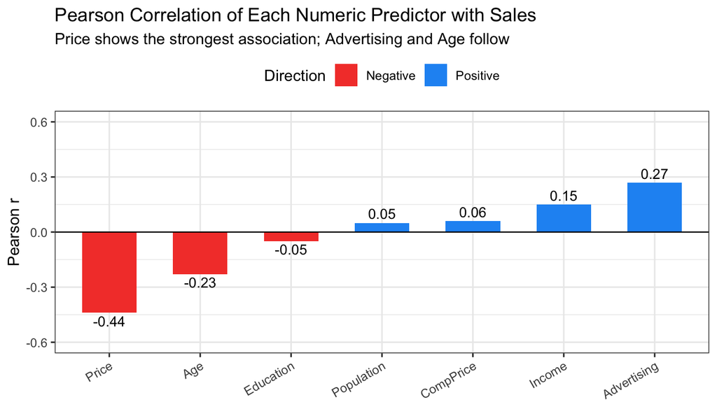

```r
ggplot(cor_with_sales, aes(x = Variable, y = Correlation, fill = Direction)) +
  geom_col(width = 0.6) +
  geom_hline(yintercept = 0, linewidth = 0.4) +
  geom_text(
    aes(label = Correlation, vjust = ifelse(Correlation >= 0, -0.4, 1.3)),
    size = 3.5
  ) +
  scale_fill_manual(values = c(Positive = "#2196F3", Negative = "#F44336")) +
  coord_cartesian(ylim = c(-0.6, 0.6)) +
  labs(
    title    = "Pearson Correlation of Each Numeric Predictor with Sales",
    subtitle = "Price shows the strongest association; Advertising and Age follow",
    x = NULL, y = "Pearson r"
  ) +
  theme_bw(base_size = 11) +
  theme(
    legend.position = "top",
    axis.text.x = element_text(angle = 30, hjust = 1)
  )
```

**Findings:** `Price` has the strongest linear relationship with `Sales` (r = −0.44), followed by `Advertising` (r = 0.27) and `Age` (r = −0.23). `Income`, `CompPrice`, `Education`, and `Population` show near-zero correlations and were excluded from the model.